# R Notebook

```r
library(tidyverse)
library(readxl)
library(here)
library(janitor)
library(GGally)
library(modelr)
library(pROC)
library(broom)
library(caret)
```

```r
telecomms <- read_excel("data/telecomms_churn.xlsx")
telecomms <- clean_names(telecomms)
dim(telecomms)
```

```
[1] 7043   12
```

```r
summary(telecomms)
```

```
 customer_id           gender          senior_citizen     partner           dependents
 Length:7043        Length:7043        Min.   :0.0000   Length:7043        Length:7043
 Class :character   Class :character   1st Qu.:0.0000   Class :character   Class :character
 Mode  :character   Mode  :character   Median :0.0000   Mode  :character   Mode  :character
                                       Mean   :0.1621
                                       3rd Qu.:0.0000
                                       Max.   :1.0000

     tenure      phone_service      internet_service     contract         monthly_charges
 Min.   : 0.00   Length:7043        Length:7043        Length:7043        Min.   : 18.25
 1st Qu.: 9.00   Class :character   Class :character   Class :character   1st Qu.: 35.50
 Median :29.00   Mode  :character   Mode  :character   Mode  :character   Median : 70.35
 Mean   :32.37                                                            Mean   : 64.76
 3rd Qu.:55.00                                                            3rd Qu.: 89.85
 Max.   :72.00                                                            Max.   :118.75

 total_charges       churn
 Min.   :  18.8   Length:7043
 1st Qu.: 401.4   Class :character
 Median :1397.5   Mode  :character
 Mean   :2283.3
 3rd Qu.:3794.7
 Max.   :8684.8
 NA's   :11
```

```r
telecomms <- telecomms %>%
  drop_na()
```

7032 rows and 12 columns And we have only 11 NA in total_charges I don’t need customer id

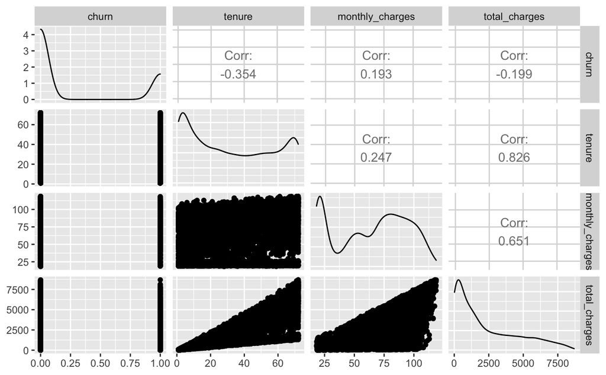

```r
telecomms <- telecomms %>%
  select(-customer_id) %>%
  mutate_at("senior_citizen", is.logical) %>%
  mutate(churn = as.numeric(ifelse(churn == "No", 0, 1)))

telecomms %>%
  select(churn, tenure, monthly_charges, total_charges) %>%
  ggpairs()
```

Tenure is the continuos varibale more corelated with churn.

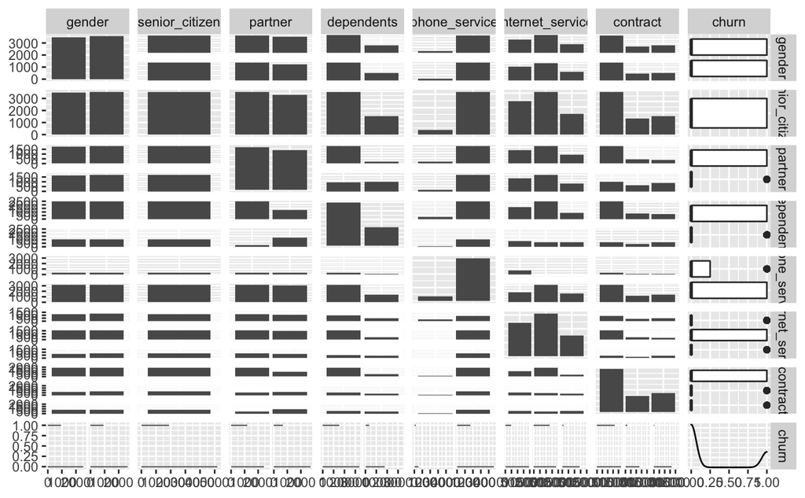

```r
telecomms %>%
  select(-c(tenure, monthly_charges, total_charges)) %>%
  ggpairs()
```

One of the type of contract looks correlated, also the internet service, the telephone service are correlated. Dependents and partners looks correlated but they looks also correlated between them.

```r
telecomms <- telecomms %>%
  mutate_if(is.character, as.factor)
```

The tenure looks very related so let’s do our first model with it

```r
model_tenure <- glm(churn ~ tenure, data = telecomms, family = binomial(link = "logit"))
model_tenure
```

```
Call:  glm(formula = churn ~ tenure, family = binomial(link = "logit"),
    data = telecomms)

Coefficients:
(Intercept)       tenure
    0.03730     -0.03901

Degrees of Freedom: 7031 Total (i.e. Null);  7030 Residual
Null Deviance:      8143
Residual Deviance: 7176     AIC: 7180
```

```r
tidy(model_tenure)
```

| term | estimate | std.error | statistic | p.value |
| --- | --- | --- | --- | --- |
| (Intercept) | 0.03729859 | 0.042319295 | 0.8813613 | 3.781223e-01 |
| tenure | -0.03900965 | 0.001408723 | -27.6914926 | 8.839967e-169 |

```r
glance(model_tenure)
```

| null.deviance | df.null | logLik | AIC | BIC | deviance | df.residual |
| --- | --- | --- | --- | --- | --- | --- |
| 8143.355 | 7031 | -3588.13 | 7180.261 | 7193.977 | 7176.261 | 7030 |

The p value of tenure is < 0.05 so we should cosidering work with tenure

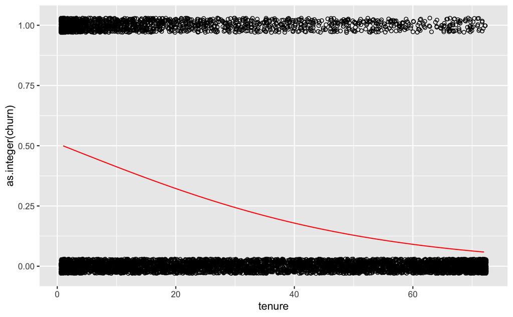

```r
max <- max(telecomms$tenure)
min <- min(telecomms$tenure)
predict_log <- tibble(tenure = seq(min, max, 1)) %>%
              add_predictions(model_tenure, type = 'response') # argument type = 'response' is used in glm models
ggplot(telecomms) +
  geom_jitter(aes(x = tenure, y = as.integer(churn)), shape = 1,
              position = position_jitter(h = 0.03))  +
   geom_line(data = predict_log, aes(x = tenure , y = pred), col = 'red')
```

contract will be our categorical variable

```r
model_contract <- glm(churn ~ contract, data = telecomms, family = binomial(link = "logit"))
model_contract
```

```
Call:  glm(formula = churn ~ contract, family = binomial(link = "logit"),
    data = telecomms)

Coefficients:
     (Intercept)  contractOne year  contractTwo year
         -0.2937           -1.7690           -3.2357

Degrees of Freedom: 7031 Total (i.e. Null);  7029 Residual
Null Deviance:      8143
Residual Deviance: 6763     AIC: 6769
```

```r
tidy(model_contract)
```

| term | estimate | std.error | statistic | p.value |
| --- | --- | --- | --- | --- |
| (Intercept) | -0.2937062 | 0.03247584 | -9.043837 | 1.512667e-19 |
| contractOne year | -1.7690303 | 0.08856903 | -19.973464 | 9.372290e-89 |
| contractTwo year | -3.2357134 | 0.14999583 | -21.572022 | 3.289969e-103 |

```r
glance(model_contract)
```

| null.deviance | df.null | logLik | AIC | BIC | deviance | df.residual |
| --- | --- | --- | --- | --- | --- | --- |
| 8143.355 | 7031 | -3381.26 | 6768.521 | 6789.095 | 6762.521 | 7029 |

Also the p values of the 3 different types of contract are lower than 0.05, and the AIC and BIC look better than in the model with tenure.

```r
model_all <- glm(churn ~ ., data = telecomms, family = binomial(link = "logit"))
model_all
```

```
Call:  glm(formula = churn ~ ., family = binomial(link = "logit"), data = telecomms)

Coefficients:
                (Intercept)                   genderMale           senior_citizenTRUE
                   0.134888                    -0.014525                           NA
                 partnerYes                dependentsYes                       tenure
                   0.052583                    -0.271245                    -0.058549
           phone_serviceYes  internet_serviceFiber optic           internet_serviceNo
                  -0.823491                     0.980383                    -0.516846
           contractOne year             contractTwo year              monthly_charges
                  -0.872017                    -1.761533                     0.007111
              total_charges
                   0.000289

Degrees of Freedom: 7031 Total (i.e. Null);  7020 Residual
Null Deviance:      8143
Residual Deviance: 5995     AIC: 6019
```

```r
tidy(model_all)
```

| term | estimate | std.error | statistic | p.value |
| --- | --- | --- | --- | --- |
| (Intercept) | 0.1348880999 | 1.973201e-01 | 0.6836004 | 4.942275e-01 |
| genderMale | -0.0145251270 | 6.355943e-02 | -0.2285283 | 8.192356e-01 |
| partnerYes | 0.0525828699 | 7.563038e-02 | 0.6952612 | 4.868916e-01 |
| dependentsYes | -0.2712448393 | 8.652837e-02 | -3.1347503 | 1.720004e-03 |
| tenure | -0.0585486299 | 6.129472e-03 | -9.5519860 | 1.272335e-21 |
| phone_serviceYes | -0.8234910084 | 1.432119e-01 | -5.7501561 | 8.916110e-09 |
| internet_serviceFiber optic | 0.9803834135 | 1.307278e-01 | 7.4994262 | 6.409778e-14 |
| internet_serviceNo | -0.5168455227 | 1.849508e-01 | -2.7945021 | 5.197970e-03 |
| contractOne year | -0.8720169503 | 1.045706e-01 | -8.3390233 | 7.490668e-17 |
| contractTwo year | -1.7615328316 | 1.727183e-01 | -10.1988757 | 2.005809e-24 |

[output cut: 2 more lines]

```r
glance(model_all)
```

| null.deviance | df.null | logLik | AIC | BIC | deviance | df.residual |
| --- | --- | --- | --- | --- | --- | --- |
| 8143.355 | 7031 | -2997.574 | 6019.147 | 6101.446 | 5995.147 | 7020 |

senior_citizen, gender, partner and monthly_charges have a p value > 0.05 so we will not take them

```r
model_all_1 <- glm(churn ~ dependents + tenure + phone_service + internet_service
                   + contract + total_charges, data = telecomms, family = binomial(link = "logit"))
model_all_1
```

```
Call:  glm(formula = churn ~ dependents + tenure + phone_service + internet_service +
    contract + total_charges, family = binomial(link = "logit"),
    data = telecomms)

Coefficients:
                (Intercept)                dependentsYes                       tenure
                  0.4133337                   -0.2439033                   -0.0615468
           phone_serviceYes  internet_serviceFiber optic           internet_serviceNo
                 -0.7032288                    1.1540776                   -0.7608828
           contractOne year             contractTwo year                total_charges
                 -0.8498629                   -1.7395355                    0.0003482

Degrees of Freedom: 7031 Total (i.e. Null);  7023 Residual
Null Deviance:      8143
Residual Deviance: 5999     AIC: 6017
```

```r
tidy(model_all_1)
```

| term | estimate | std.error | statistic | p.value |
| --- | --- | --- | --- | --- |
| (Intercept) | 0.4133337124 | 1.183273e-01 | 3.493138 | 4.773804e-04 |
| dependentsYes | -0.2439032922 | 7.908047e-02 | -3.084242 | 2.040717e-03 |
| tenure | -0.0615467641 | 5.862095e-03 | -10.499108 | 8.720062e-26 |
| phone_serviceYes | -0.7032288440 | 1.266538e-01 | -5.552373 | 2.818181e-08 |
| internet_serviceFiber optic | 1.1540776080 | 9.114063e-02 | 12.662603 | 9.528667e-37 |
| internet_serviceNo | -0.7608827614 | 1.269547e-01 | -5.993341 | 2.055736e-09 |
| contractOne year | -0.8498629154 | 1.038469e-01 | -8.183802 | 2.750247e-16 |
| contractTwo year | -1.7395354560 | 1.724934e-01 | -10.084649 | 6.459575e-24 |
| total_charges | 0.0003481918 | 6.224246e-05 | 5.594120 | 2.217432e-08 |

```r
glance(model_all_1)
```

| null.deviance | df.null | logLik | AIC | BIC | deviance | df.residual |
| --- | --- | --- | --- | --- | --- | --- |
| 8143.355 | 7031 | -2999.517 | 6017.035 | 6078.759 | 5999.035 | 7023 |

The model has a better result with the extraction of the variables that have a p value > 0.05

[figure not shown]

```r
auc(roc_tenure)
```

```
Area under the curve: 0.7414
```

```r
auc(roc_contract)
```

```
Area under the curve: 0.7386
```

```r
auc(roc_all_1)
```

```
Area under the curve: 0.8383
```

The best model continue to be the last one with 6 predictors

```r
train_control <- trainControl(method = "repeatedcv",
                              number = 5,
                              repeats = 100,
                              savePredictions = TRUE,
                              classProbs = TRUE,
                              summaryFunction = twoClassSummary)
```

```r
telecomms <- telecomms %>%
  mutate(churn = as.factor(ifelse(churn == 1, "Yes", "No")))
```

```r
summary(model_cv_tenure)
```

```
Call:
NULL

Deviance Residuals:
    Min       1Q   Median       3Q      Max
-1.1767  -0.8401  -0.4788   1.1781   2.3800

Coefficients:
             Estimate Std. Error z value Pr(>|z|)
(Intercept)  0.037299   0.042319   0.881    0.378
tenure      -0.039010   0.001409 -27.691   <2e-16 ***
---
Signif. codes:  0 ‘***’ 0.001 ‘**’ 0.01 ‘*’ 0.05 ‘.’ 0.1 ‘ ’ 1

(Dispersion parameter for binomial family taken to be 1)

    Null deviance: 8143.4  on 7031  degrees of freedom
Residual deviance: 7176.3  on 7030  degrees of freedom
AIC: 7180.3

Number of Fisher Scoring iterations: 4
```

```r
summary(model_cv_contract)
```

```
Call:
NULL

Deviance Residuals:
    Min       1Q   Median       3Q      Max
-1.0555  -1.0555  -0.4892   1.3044   2.6677

Coefficients:
                   Estimate Std. Error z value Pr(>|z|)
(Intercept)        -0.29371    0.03248  -9.044   <2e-16 ***
`contractOne year` -1.76903    0.08857 -19.973   <2e-16 ***
`contractTwo year` -3.23571    0.15000 -21.572   <2e-16 ***
---
Signif. codes:  0 ‘***’ 0.001 ‘**’ 0.01 ‘*’ 0.05 ‘.’ 0.1 ‘ ’ 1

(Dispersion parameter for binomial family taken to be 1)

    Null deviance: 8143.4  on 7031  degrees of freedom
Residual deviance: 6762.5  on 7029  degrees of freedom
AIC: 6768.5

Number of Fisher Scoring iterations: 6
```

```r
summary(model_cv_all_1)
```

```
Call:
NULL

Deviance Residuals:
    Min       1Q   Median       3Q      Max
-1.5467  -0.7220  -0.3016   0.8514   3.4759

Coefficients:
                                Estimate Std. Error z value Pr(>|z|)
(Intercept)                    4.133e-01  1.183e-01   3.493 0.000477 ***
dependentsYes                 -2.439e-01  7.908e-02  -3.084 0.002041 **
tenure                        -6.155e-02  5.862e-03 -10.499  < 2e-16 ***
phone_serviceYes              -7.032e-01  1.267e-01  -5.552 2.82e-08 ***
`internet_serviceFiber optic`  1.154e+00  9.114e-02  12.663  < 2e-16 ***
internet_serviceNo            -7.609e-01  1.270e-01  -5.993 2.06e-09 ***
`contractOne year`            -8.499e-01  1.038e-01  -8.184 2.75e-16 ***
`contractTwo year`            -1.740e+00  1.725e-01 -10.085  < 2e-16 ***
total_charges                  3.482e-04  6.224e-05   5.594 2.22e-08 ***
---
Signif. codes:  0 ‘***’ 0.001 ‘**’ 0.01 ‘*’ 0.05 ‘.’ 0.1 ‘ ’ 1

(Dispersion parameter for binomial family taken to be 1)

    Null deviance: 8143.4  on 7031  degrees of freedom
Residual deviance: 5999.0  on 7023  degrees of freedom
AIC: 6017

Number of Fisher Scoring iterations: 6
```

```r
model_cv_tenure$results
```

|  | parameter | ROC | Sens | Spec | ROCSD | SensSD | SpecSD |
| --- | --- | --- | --- | --- | --- | --- | --- |
| 1 | none | 0.7414495 | 0.9793115 | 0.08790706 | 0.01332753 | 0.02365604 | 0.09950356 |

```r
model_cv_contract$results
```

|  | parameter | ROC | Sens | Spec | ROCSD | SensSD | SpecSD |
| --- | --- | --- | --- | --- | --- | --- | --- |
| 1 | none | 0.7385974 | 1 | 0 | 0.009733178 | 0 | 0 |

```r
model_cv_all_1$results
```

|  | parameter | ROC | Sens | Spec | ROCSD | SensSD | SpecSD |
| --- | --- | --- | --- | --- | --- | --- | --- |
| 1 | none | 0.8374539 | 0.8887895 | 0.5288918 | 0.009728564 | 0.009467931 | 0.02192536 |

So in conclusion the model with the 6 predictors works better have the higher auc also in cv We will take a theshold of 0.5 that is the one that the cv use.

```r
threshold <- 0.5
telecomms_pred <- telecomms %>%
  add_predictions(model_all_1) %>%
  mutate(pred_thresh_0.5 = pred >= threshold)
```

```r
telecomms_pred %>%
  tabyl(churn, pred_thresh_0.5)
```

[output not shown]

The accuracy is:

```r
(4935 + 602) /(4935 + 602 + 228 + 1267)
```

```
[1] 0.7874005
```

The accuracy is 78.74% it isn’t terrible bad but probably for a company could be horrible, let’s check the balance in the dataset

```r
telecomms %>%
  filter(churn == 1) %>%
  count()
```

| n |
| --- |
| 1869 |

```r
telecomms %>%
  filter(churn == 0) %>%
  count()
```

| n |
| --- |
| 5163 |

The data is very unbalanced so the accurancy isn’t a great parameter, we have 1869 churn and 5163 that continue with the contract

```r
NTP <- 4935
NTN <- 602
NFP <- 228
NFN <- 1267

TPR <- NTP / (NTP + NFN)
TPR
```

```
[1] 0.7957111
```

```r
TNR <- NTN / (NTN + NFP)
TNR
```

```
[1] 0.7253012
```

```r
FPR <- NFP / (NFP + NTN)
FPR
```

```
[1] 0.2746988
```

```r
FNR <- NFN / (NFN + NTP)
FNR
```

```
[1] 0.2042889
```

EXTENSION

[output not shown]

```r
(0.8374539  - 0.8369457) * 100
```

```
[1] 0.05082
```

```r
telecomms_all <- telecomms %>%
  add_predictions(model_all, type = "response")
```

```
prediction from a rank-deficient fit may be misleading
```

```r
roc_all <- telecomms_all %>%
  roc(response = churn, predictor = pred)
classifier_data <- tibble(
  threshold = roc_all$thresholds,
  tpr = roc_all$sensitivities,
  tnr = roc_all$specificities
)

classifier_data <- classifier_data %>%
  mutate(
    fpr = 1 - tnr,
    fnr = 1 - tpr
  )
```

```r
prob_pos = (telecomms %>%
  filter(churn == 1) %>%
  count())/nrow(telecomms)
prob_neg = (telecomms %>%
  filter(churn == 0) %>%
  count())/nrow(telecomms)
```

```r
tpp <-(telecomms %>%
  filter(churn == 0) %>%
  summarise(mean = mean(total_charges)))-100
tnp <- 0
fpp <- -100
fnp <- 0
```

[figure not shown]

```r
classifier_data %>%
  filter(profit == max(profit))
```

| threshold | tpr | tnr | fpr | fnr | profit |
| --- | --- | --- | --- | --- | --- |
| 0.03986681 | 0.9839486 | 0.3025373 | 0.6974627 | 0.01605136 | 590.9098 |

The max profit with with a threshold of 0.03986681

```r
threshold <- 0.03986681
telecomms_pred_1 <- telecomms %>%
  add_predictions(model_all) %>%
  mutate(pred_thresh = pred >= threshold)
```

```
prediction from a rank-deficient fit may be misleading
```

```r
telecomms_pred_1 %>%
  tabyl(churn, pred_thresh)
```

```
 churn FALSE TRUE
     0  4620  543
     1   894  975
```

```r
(4620 + 975) / (4620 + 975 + 894 + 543)
```

```
[1] 0.7956485
```

The accuracy is 0.7956485

```r
NTP <- 4620
NTN <- 975
NFP <- 543
NFN <- 894

TPR <- NTP / (NTP + NFN)
TPR
```

```
[1] 0.8378672
```

```r
TNR <- NTN / (NTN + NFP)
TNR
```

```
[1] 0.6422925
```

```r
FPR <- NFP / (NFP + NTN)
FPR
```

```
[1] 0.3577075
```

```r
FNR <- NFN / (NFN + NTP)
FNR
```

```
[1] 0.1621328
```